# XP-GWAS: a method for identifying trait-associated variants by sequencing pools of individuals selected from a diversity panel

Schnable Lab

July 8, 2015

## SUMMARY:

Although approaches for conducting genome-wide association studies (GWAS) are well developed, conventional GWAS requires the high-density genotyping of large numbers of individuals from a diversity panel. Here we report a method for conducting GWAS that does not require the genotyping of large numbers of individuals. Instead XP-GWAS (extreme phenotype GWAS) relies on genotyping pools of individuals from a diversity panel having extreme phenotypes. This analysis measures allele frequencies in the extreme pools, enabling the discovery of associations between genetic variants and traits of interest.

## CITATION:

Yang et al., The Plant Journal, 2015

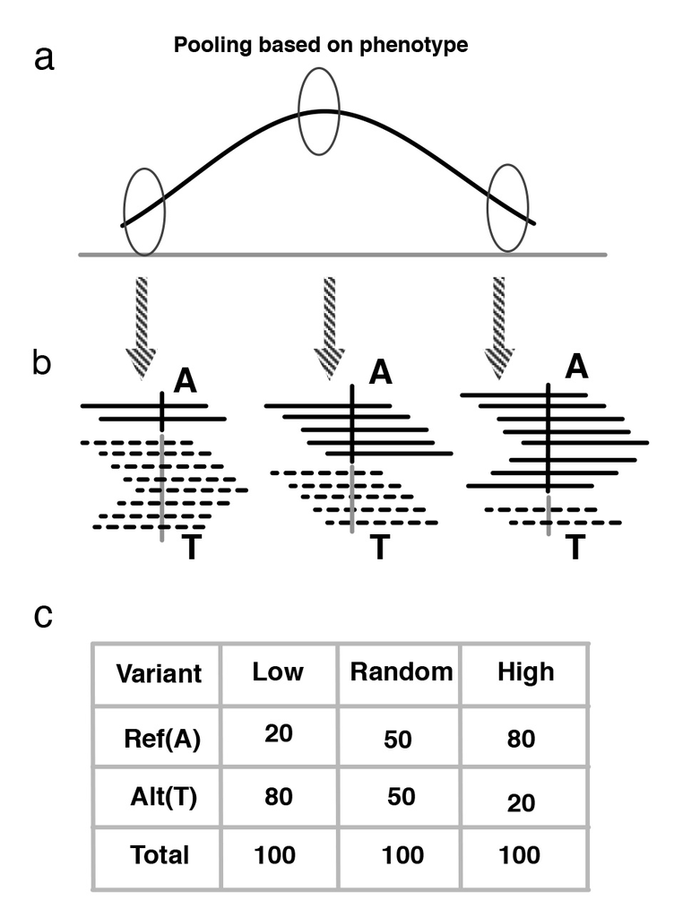

**Simplified scheme for XP-GWAS by investigating the allele frequencies in different phenotypic pools.** (a) According to the phenotypic distribution in a diversity panel, accessions with high, low or random phenotypes will be pooled for sequencing. (b) De novo variants discovery were conducted and number of reads supported for reference variant call and alternative variant call were computed in each of the phenotypic pools. (c) The variant counts at each locus were subjected for statistical test.

## Statistical Procedure: